# Chapter 8: Linear Regression with Multiple Predictors

# Overview

- 8 Linear regression with multiple predictors
  - 8.1 Indicator and categorical predictors
  - 8.2 Many predictors in a model
  - 8.3 Adjusted R-squared
  - 8.4 Model selection
    - 8.4.1 Stepwise selection
    - 8.4.2 Other model selection strategies

# 8.1 Indicator and categorical predictors

## Indicator variables

```r
glimpse(loans)
```

```
Rows: 10,000
Columns: 8
$ interest_rate   <dbl> 14.07, 12.61, 17.09, 6.72, 14.07, 6.72, 13.59, 11.99, 13.59, 6.71, 15.04, …
$ verified_income <fct> Verified, Not Verified, Source Verified, Not Verified, Verified, Not Verif…
$ debt_to_income  <dbl> 18.01, 5.04, 21.15, 10.16, 57.96, 6.46, 23.66, 16.19, 36.48, 18.91, 10.45,…
$ credit_util     <dbl> 0.54759517, 0.15003472, 0.66134832, 0.19673228, 0.75490772, 0.09258907, 0.…
$ bankruptcy      <fct> 0, 1, 0, 0, 0, 0, 0, 0, 0, 0, 1, 0, 0, 0, 1, 0, 0, 0, 0, 0, 0, 1, 0, 0, 0,…
$ term            <dbl> 60, 36, 36, 36, 36, 36, 60, 60, 36, 36, 60, 60, 36, 60, 36, 60, 60, 60, 36…
$ credit_checks   <int> 6, 1, 4, 0, 7, 6, 1, 1, 3, 0, 4, 4, 8, 6, 0, 0, 4, 6, 2, 1, 0, 4, 1, 1, 1,…
$ issue_month     <fct> Mar-2018, Feb-2018, Feb-2018, Jan-2018, Mar-2018, Jan-2018, Jan-2018, Jan-…
```

`bankruptcy` is an *indicator* (categorical 0 or 1) variable with two levels:

- 0 means the borrower has not had a bankruptcy in the past.
- 1 means the borrower has had a bankruptcy in the past.

## Regression with categorical predictor

Does having a past bankruptcy predict the interest rate you get?

```r
model1 <- lm(interest_rate ~ bankruptcy, data = loans)
summary(model1)$coefficients
```

```
              Estimate Std. Error    t value     Pr(>|t|)
(Intercept) 12.3380046 0.05329827 231.489782 0.000000e+00
bankruptcy1  0.7367856 0.15290615   4.818548 1.467339e-06
```

Regression equation: $\widehat{\texttt{interest_rate}} = 12.34 + 0.74 \times \texttt{bankruptcy}$

- If `bankruptcy` is 0, $\widehat{\texttt{interest_rate}} = 12.34$.
- If `bankruptcy` is 1, $\widehat{\texttt{interest_rate}} = 12.34 + 0.74 = 13.08$.

## Predictors with more than two levels

`verified_income` has three levels:

- *Verified:* Both the source and amount of income were verified.
- *Source Verified:* Only the source was verified, not the amount.
- *Not Verified:* The income was not verified.

```r
model2 <- lm(interest_rate ~ verified_income, data = loans)
summary(model2)$coefficients
```

```
                                Estimate Std. Error   t value      Pr(>|t|)
(Intercept)                    11.099457 0.08091172 137.17985  0.000000e+00
verified_incomeSource Verified  1.416021 0.11073908  12.78700  3.785246e-37
verified_incomeVerified         3.254289 0.12969702  25.09147 8.614644e-135
```

## Interpreting a 3-level predictor

```
                                Estimate Std. Error   t value      Pr(>|t|)
(Intercept)                    11.099457 0.08091172 137.17985  0.000000e+00
verified_incomeSource Verified  1.416021 0.11073908  12.78700  3.785246e-37
verified_incomeVerified         3.254289 0.12969702  25.09147 8.614644e-135
```

$$\begin{aligned}
\widehat{\texttt{interest_rate}} &= 11.10 \\
&+ 1.42 \times \texttt{verified_income}_{\texttt{Source Verified}}
\\
&+ 3.25 \times \texttt{verified_income}_{\texttt{Verified}}
\end{aligned}$$

- The *reference level* is `Not Verified`: $\widehat{\texttt{interest_rate}} = 11.10$
- If `verified_income` is `Source Verified`, you have to add 1.42.
- If `verified_income` is `Verified`, you have to add 3.25.

## Boxplot of interest rates by verification

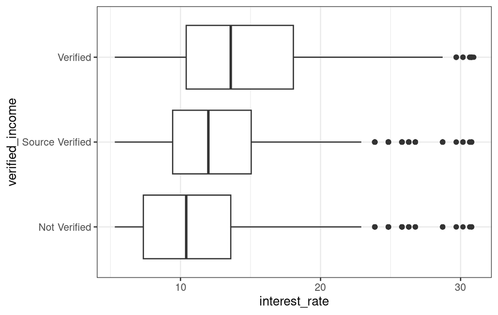

```r
ggplot(data = loans, aes(x = interest_rate, y = verified_income)) +
  geom_boxplot()
```

## Group Discussion

$$\begin{aligned}
\widehat{\texttt{interest_rate}} &= 11.10 \\
&+ 1.42 \times \texttt{verified_income}_{\texttt{Source Verified}}
\\
&+ 3.25 \times \texttt{verified_income}_{\texttt{Verified}}
\end{aligned}$$

1. Do the variables `interest_rate` and `verified_income` appear to be associated? How?
2. Can you think of a possible *confounding variable* that might account for this association?

## R-squared in model #1

```r
summary(model1)
```

```
Call:
lm(formula = interest_rate ~ bankruptcy, data = loans)

Residuals:
    Min      1Q  Median      3Q     Max
-7.7648 -3.6448 -0.4548  2.7120 18.6020

Coefficients:
            Estimate Std. Error t value Pr(>|t|)
(Intercept)  12.3380     0.0533 231.490  < 2e-16 ***
bankruptcy1   0.7368     0.1529   4.819 1.47e-06 ***
---
Signif. codes:  0 '***' 0.001 '**' 0.01 '*' 0.05 '.' 0.1 ' ' 1

Residual standard error: 4.996 on 9998 degrees of freedom
Multiple R-squared:  0.002317,  Adjusted R-squared:  0.002217
F-statistic: 23.22 on 1 and 9998 DF,  p-value: 1.467e-06
```

## R-squared in model #2

```r
summary(model2)
```

```
Call:
lm(formula = interest_rate ~ verified_income, data = loans)

Residuals:
    Min      1Q  Median      3Q     Max
-9.0437 -3.7495 -0.6795  2.5345 19.6905

Coefficients:
                               Estimate Std. Error t value Pr(>|t|)
(Intercept)                    11.09946    0.08091  137.18   <2e-16 ***
verified_incomeSource Verified  1.41602    0.11074   12.79   <2e-16 ***
verified_incomeVerified         3.25429    0.12970   25.09   <2e-16 ***
---
Signif. codes:  0 '***' 0.001 '**' 0.01 '*' 0.05 '.' 0.1 ' ' 1

Residual standard error: 4.851 on 9997 degrees of freedom
Multiple R-squared:  0.05945,   Adjusted R-squared:  0.05926
F-statistic: 315.9 on 2 and 9997 DF,  p-value: < 2.2e-16
```

## How much does the model tell us?

- Model #1 only explains about 0.2% of the variation in interest rates.
- Model #2 only explains about 6% of the variation in interest rates.

# 8.2 Many predictors in a model

## Variable descriptions

| variable | description |
| --- | --- |
| interest_rate | Interest rate on the loan, in an annual percentage. |
| verified_income | Categorical variable describing whether the borrower’s income source and amount have been verified, with levels `Verified`, `Source Verified`, and `Not Verified`. |
| debt_to_income | Debt-to-income ratio, which is the percentage of total debt of the borrower divided by their total income. |
| credit_util | Of all the credit available to the borrower, what fraction are they utilizing. For example, the credit utilization on a credit card would be the card’s balance divided by the card’s credit limit. |
| bankruptcy | An indicator variable for whether the borrower has a past bankruptcy in their record. This variable takes a value of `1` if the answer is *yes* and `0` if the answer is *no*. |
| term | The length of the loan, in months. |
| issue_month | The month and year the loan was issued, which for these loans is always during the first quarter of 2018. |
| credit_checks | Number of credit checks in the last 12 months. For example, when filing an application for a credit card, it is common for the company receiving the application to run a credit check. |

## Multiple Regression Model

$$\begin{aligned}
\widehat{\texttt{interest_rate}} &= b_0 \\
&+ b_1 \times \texttt{verified_income}_{\texttt{Source Verified}} \\
&+ b_2 \times \texttt{verified_income}_{\texttt{Verified}} \\
&+ b_3 \times \texttt{debt_to_income} \\
&+ b_4 \times \texttt{credit_util} \\
&+ b_5 \times \texttt{bankruptcy} \\
&+ b_6 \times \texttt{term} \\
&+ b_9 \times \texttt{credit_checks} \\
&+ b_7 \times \texttt{issue_month}_{\texttt{Jan-2018}} \\
&+ b_8 \times \texttt{issue_month}_{\texttt{Mar-2018}}
\end{aligned}$$

## Multiple Regression in R

```r
model3 <- lm(interest_rate ~ verified_income + debt_to_income + credit_util +
               bankruptcy + term + credit_checks + issue_month, data = loans)
summary(model3)$coefficients
```

```
                                  Estimate  Std. Error    t value      Pr(>|t|)
(Intercept)                     1.89383908 0.210244919  9.0077757  2.488270e-19
verified_incomeSource Verified  0.99746793 0.099186920 10.0564463  1.115899e-23
verified_incomeVerified         2.56316801 0.117183771 21.8730631 1.254494e-103
debt_to_income                  0.02183207 0.002936979  7.4335140  1.144512e-13
credit_util                     4.89698768 0.161886997 30.2494194 2.212471e-192
bankruptcy1                     0.39110510 0.132285604  2.9565205  3.118611e-03
term                            0.15338772 0.003944235 38.8890942 3.932211e-308
credit_checks                   0.22832063 0.018242346 12.5159682  1.131742e-35
issue_monthJan-2018             0.04550986 0.108034334  0.4212536  6.735790e-01
issue_monthMar-2018            -0.04162440 0.106545393 -0.3906729  6.960474e-01
```

## Equation for fitted model

$$\begin{aligned}
\widehat{\texttt{interest_rate}} &= 1.89 \\
&+ 1.00 \times \texttt{verified_income}_{\texttt{Source Verified}}
\\
&+ 2.56 \times \texttt{verified_income}_{\texttt{Verified}} \\
&+ 0.02 \times \texttt{debt_to_income} \\
&+ 4.90 \times \texttt{credit_util} \\
&+ 0.39 \times \texttt{bankruptcy} \\
&+ 0.15 \times \texttt{term} \\
&+ 0.23 \times \texttt{credit_checks} \\
&+ 0.05 \times \texttt{issue_month}_{\texttt{Jan-2018}} \\
&- 0.04 \times \texttt{issue_month}_{\texttt{Mar-2018}}
\end{aligned}$$

## Group Exercise

$$\scriptsize{
\begin{aligned}
&\widehat{\texttt{interest_rate}} = 1.89 \\
&+ 1.00 \times \texttt{verified_income}_{\texttt{Source Verified}}
\\
&+ 2.56 \times \texttt{verified_income}_{\texttt{Verified}} \\
&+ 0.02 \times \texttt{debt_to_income} \\
&+ 4.90 \times \texttt{credit_util} \\
&+ 0.39 \times \texttt{bankruptcy} \\
&+ 0.15 \times \texttt{term} \\
&+ 0.23 \times \texttt{credit_checks} \\
&+ 0.05 \times \texttt{issue_month}_{\texttt{Jan-2018}} \\
&- 0.04 \times \texttt{issue_month}_{\texttt{Mar-2018}}
\end{aligned} }$$

1. Interpret the coefficients of `credit_checks` and `bankruptcy`.
2. Predict the interest rate of a borrower with the following characteristics:
- Income is Source Verified
- Debt-to-income is 21
- Credit utilized is 0.32
- Never has had a bankruptcy
- Term of loan is 36 months
- Number of credit checks is 3
- Loan is issued in March

# 8.3 Adjusted R-squared

## Full summary of regression model

```r
summary(model3)
```

```
Call:
lm(formula = interest_rate ~ verified_income + debt_to_income +
    credit_util + bankruptcy + term + credit_checks + issue_month,
    data = loans)

Residuals:
     Min       1Q   Median       3Q      Max
-12.1219  -3.0984  -0.7247   2.3318  18.8160

Coefficients:
                                Estimate Std. Error t value Pr(>|t|)
(Intercept)                     1.893839   0.210245   9.008  < 2e-16 ***
verified_incomeSource Verified  0.997468   0.099187  10.056  < 2e-16 ***
verified_incomeVerified         2.563168   0.117184  21.873  < 2e-16 ***
debt_to_income                  0.021832   0.002937   7.434 1.14e-13 ***
credit_util                     4.896988   0.161887  30.249  < 2e-16 ***
bankruptcy1                     0.391105   0.132286   2.957  0.00312 **
term                            0.153388   0.003944  38.889  < 2e-16 ***
credit_checks                   0.228321   0.018242  12.516  < 2e-16 ***
issue_monthJan-2018             0.045510   0.108034   0.421  0.67358
issue_monthMar-2018            -0.041624   0.106545  -0.391  0.69605
---
Signif. codes:  0 '***' 0.001 '**' 0.01 '*' 0.05 '.' 0.1 ' ' 1

Residual standard error: 4.3 on 9964 degrees of freedom
  (26 observations deleted due to missingness)
Multiple R-squared:  0.2604,    Adjusted R-squared:  0.2597
F-statistic: 389.7 on 9 and 9964 DF,  p-value: < 2.2e-16
```

## Multiple and Adjusted R-squared

- *Multiple* $R^2$ estimates the percentage of variability in the response variable that is explained by the model.
  - This combination of variables explains about 26% of the variability in interest rate.
- *Adjusted* $R^2$ takes into account the complexity of the model.
  - Adding explanatory variables will always increase the multiple $R^2$, but you might be *overfitting* the data (using too complex a model).
  - If you add an explanatory variable to a model and the Adjusted $R^2$ goes *down*, you probably have too many variables.

# 8.4 Model selection

## 8.4.1 Stepwise selection

The `step` function in R attempts to eliminate explanatory variables that aren’t needed.

- It computes a score (the AIC) that measures how good the model is. (lower is better)
- It tries eliminating variables that *decrease* the AIC.

## Using `step`

```r
step(model3)
```

```
Start:  AIC=29106.05
interest_rate ~ verified_income + debt_to_income + credit_util +
    bankruptcy + term + credit_checks + issue_month

                  Df Sum of Sq    RSS   AIC
- issue_month      2      13.3 184240 29103
<none>                         184227 29106
- bankruptcy       1     161.6 184389 29113
- debt_to_income   1    1021.7 185249 29159
- credit_checks    1    2896.3 187123 29260
- verified_income  2    8845.9 193073 29570
- credit_util      1   16918.2 201145 29980
- term             1   27962.5 212190 30514

Step:  AIC=29102.77
interest_rate ~ verified_income + debt_to_income + credit_util +
    bankruptcy + term + credit_checks

                  Df Sum of Sq    RSS   AIC
<none>                         184240 29103
- bankruptcy       1     162.1 184402 29110
- debt_to_income   1    1023.7 185264 29156
- credit_checks    1    2898.7 187139 29256
- verified_income  2    8836.1 193076 29566
- credit_util      1   16921.3 201162 29977
- term             1   27964.1 212204 30510
```

```
Call:
lm(formula = interest_rate ~ verified_income + debt_to_income +
    credit_util + bankruptcy + term + credit_checks, data = loans)

Coefficients:
                   (Intercept)  verified_incomeSource Verified         verified_incomeVerified
                       1.89628                         0.99625                         2.56076
                debt_to_income                     credit_util                     bankruptcy1
                       0.02185                         4.89648                         0.39164
                          term                   credit_checks
                       0.15336                         0.22841
```

## Improved model

```r
model4 <- lm(formula = interest_rate ~ verified_income + debt_to_income +
    credit_util + bankruptcy + term + credit_checks, data = loans)
summary(model4)
```

```
Call:
lm(formula = interest_rate ~ verified_income + debt_to_income +
    credit_util + bankruptcy + term + credit_checks, data = loans)

Residuals:
     Min       1Q   Median       3Q      Max
-12.0844  -3.1100  -0.7282   2.3475  18.8608

Coefficients:
                               Estimate Std. Error t value Pr(>|t|)
(Intercept)                    1.896283   0.198294   9.563  < 2e-16 ***
verified_incomeSource Verified 0.996255   0.099139  10.049  < 2e-16 ***
verified_incomeVerified        2.560756   0.117131  21.862  < 2e-16 ***
debt_to_income                 0.021852   0.002937   7.441 1.08e-13 ***
credit_util                    4.896475   0.161845  30.254  < 2e-16 ***
bankruptcy1                    0.391645   0.132272   2.961  0.00307 **
term                           0.153356   0.003943  38.893  < 2e-16 ***
credit_checks                  0.228409   0.018241  12.522  < 2e-16 ***
---
Signif. codes:  0 '***' 0.001 '**' 0.01 '*' 0.05 '.' 0.1 ' ' 1

Residual standard error: 4.3 on 9966 degrees of freedom
  (26 observations deleted due to missingness)
Multiple R-squared:  0.2603,    Adjusted R-squared:  0.2598
F-statistic:   501 on 7 and 9966 DF,  p-value: < 2.2e-16
```

## Too many variables?

- Model #3 (with all the variables) has an adjusted $R^2$ of 0.2597.
- Model #4 (without issue_month) has an adjusted $R^2$ of 0.2598.
  - This suggests that the variable `issue_month` isn’t helping the predictive power of the model, so we shouldn’t include it.